# MA304: Data Visualisation Final Project

2201687

2023-04-18

## Introduction

This project was created with the goal of analysing data from the Dallas Police Department as part of the Data Science for Good initiative [1]. All data in this project from the Dallas police Department only covers Jan 2016 - Jan 2017. There is a stereotype that police departments in the US suffer from ingrained and institutionalised bigotry; therefore, the objective of this project is to analyse the data provided and attempt to establish if there is enough evidence to suggest that this stereotype can be accurately applied to Dallas PD for the year of 2016. It is understood this is a controversial topic to engage in - however, due to the severe impacts it could have on individuals, it is the belief of this paper that it is an important area which needs to be thoroughly analysed.

## Data Cleaning and Pre-processing

```r
df <- read.csv("M:\\pc\\desktop\\Data Vis\\37-00049_UOF-P_2016_prepped.csv") #Read in the dataset being used for this project
df <- df[-1,] #Remove descriptive row to avoid confusion in dataset analysis
df$LOCATION_STATE <- NULL #Remove pointless columns from the dataset.
df$LOCATION_CITY <- NULL
#This is a dataset of Dallas police records, these column only display one value
df$OFFICER_YEARS_ON_FORCE <- as.numeric(df$OFFICER_YEARS_ON_FORCE) #Set as numeric to enable use in later code
df$SUBJECT_GENDER <- ifelse(df$SUBJECT_GENDER == "NULL", "Unknown", df$SUBJECT_GENDER)
df$SUBJECT_RACE <- ifelse(df$SUBJECT_RACE == "NULL", "Other", df$SUBJECT_RACE)
#remove empty sections to make data analysis easier and less bias.
df$OFFICER_GENDER_NUM <- ifelse(df$OFFICER_GENDER == "Male", 1,
                                ifelse(df$OFFICER_GENDER == "Female", 2, 0))
df$SUBJECT_GENDER_NUM <- ifelse(df$SUBJECT_GENDER == "Male", 1,
                                ifelse(df$SUBJECT_GENDER == "Female", 2, 0))
df$SUBJECT_INJURY_NUM <- ifelse(df$SUBJECT_INJURY == "Yes", 1, 0)
df$OFFICER_INJURY_NUM <- ifelse(df$OFFICER_INJURY == "Yes", 1, 0)
df$OFFICER_HOSPITALIZATION_NUM <- ifelse(df$OFFICER_HOSPITALIZATION == "Yes", 1, 0)
df$SUBJECT_WAS_ARRESTED_NUM <- ifelse(df$SUBJECT_WAS_ARRESTED == "Yes", 1, 0)
#The above is added for later analysis models which require numeric values such as a correlation matrix.

df$INCIDENT_DATE <- lubridate::as_date(mdy(df$INCIDENT_DATE))
df$OFFICER_HIRE_DATE <- lubridate::as_date(mdy(df$OFFICER_HIRE_DATE))
#Set the above column structures to dates to unify the input format
```

## Data Analysis

Let’s first conduct some Exploratory Data Analysis to gain a better understanding of the data set we are working with.

### Time-series plot of crimes over the year

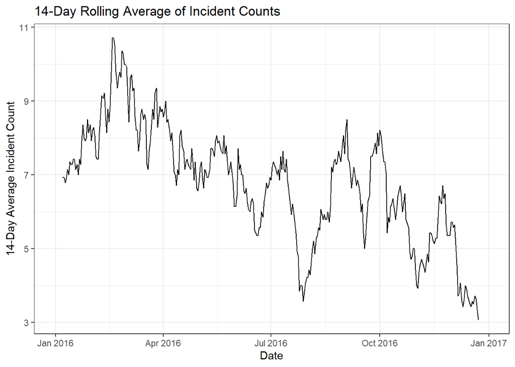

```r
# Create a new data frame with the counts of incidents per day, establish the 14 day avg, then plot.
df_dates <- df %>%
  group_by(INCIDENT_DATE) %>%
  summarize(count = n())
df_dates_avg <- df_dates %>%
  mutate(moving_avg = zoo::rollmean(count, k = 14, fill = NA, align = "center", na.rm = TRUE))
ggplot(df_dates_avg, aes(x = INCIDENT_DATE, y = moving_avg)) +
  geom_line() +
  labs(x = "Date", y = "14-Day Average Incident Count",
       title = "14-Day Rolling Average of Incident Counts") +
  theme_bw()
```

### Experience of Officers

Following on from plotting crimes over time, let’s study the experience of officers in the Dallas PD to get a better understanding of the PD’s makeup.

```r
#By creating an interactive version of this plot we can see how adjusting the bandwidth can affect how the plot is visualised.
ui <- fluidPage(
  titlePanel("Density Plot with a Bandwidth Slider"),
  sidebarLayout(
    sidebarPanel(
      sliderInput("bandwidth", "Bandwidth:",
                  min = 0.1, max = 2, value = 0.2, step = 0.1)
    ),
    mainPanel(
      plotOutput("densityplot")
    )
  )
) #Create a panel with a bandwidth slider, setting the start, end, and step values. This is the user interface used in the output.
server <- function(input, output) {

  output$densityplot <- renderPlot({
    mean_val <- mean(df$OFFICER_YEARS_ON_FORCE)
    median_val <- median(df$OFFICER_YEARS_ON_FORCE)
    linetypes <- c("Mean", "Median", "Density Curve")
    p <- ggplot(df, aes(x = OFFICER_YEARS_ON_FORCE)) +
      geom_density(fill = "blue", alpha = 0.5) +
      labs(title = "Density Plot of Officer's Years on the Force",
           x = "Years on the Force", y = "Density") +
      theme_minimal() +
      scale_x_continuous(limits = c(0, 40)) +
      geom_vline(aes(xintercept = mean_val, linetype = linetypes[1]), color = "red") +
      geom_vline(aes(xintercept = median_val, linetype = linetypes[2]), color = "green") +
      theme(legend.position = "right") +
      stat_function(fun = dnorm, args = list(mean = mean(df$OFFICER_YEARS_ON_FORCE),
                                             sd = bw.SJ(df$OFFICER_YEARS_ON_FORCE)*input$bandwidth),
                    aes(color = linetypes[3], linetype = linetypes[3]))

    p + scale_linetype_manual(values = c("dashed", "solid", "dotted"),
                              guide = guide_legend(override.aes = list(color = c("red", "red", "green"))))
  })
}#Create a function which will output a density plot
#Calculate the mean and median officer years on force; plot the density of officer years on force with correct labels, title, axis length, legend, etc.; plot lines denoting the mean and median
shinyApp(ui = ui, server = server)
```

Shiny applications not supported in static R Markdown documents

### Chance of Subject Injury based on Officer Experience

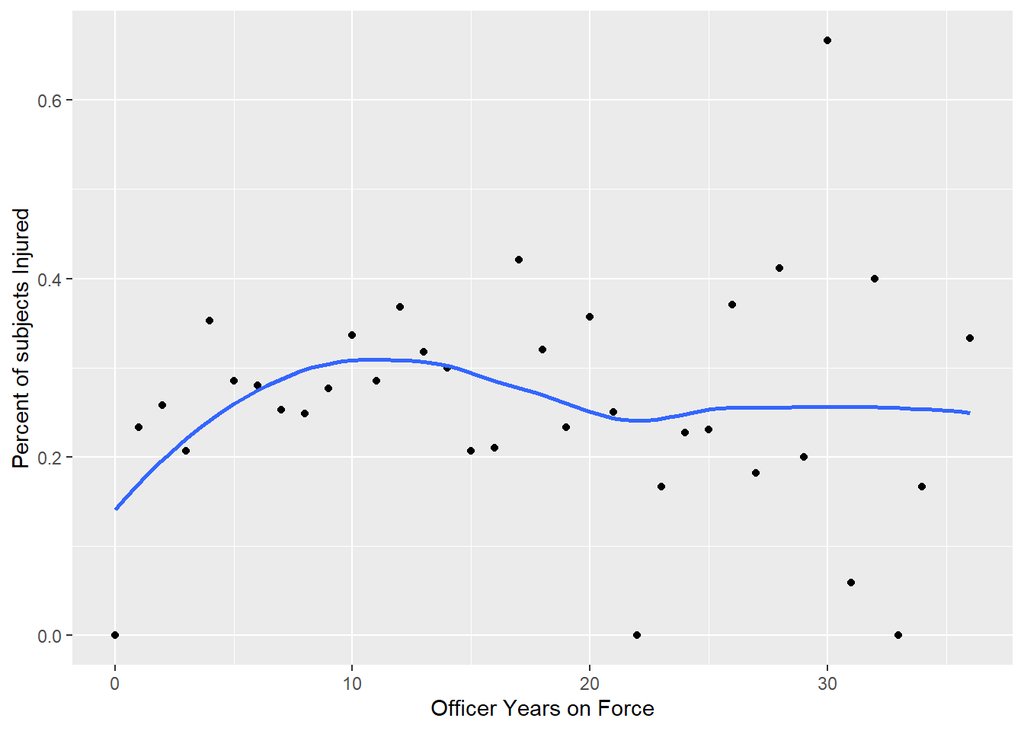

```r
#create a scatter plot showing the percentage of injured subjects depending on the officers years on the force; add a smoothed line to highlight how the trend changes as officers increase in experience.
df_percent_injured <- df %>%
  group_by(OFFICER_YEARS_ON_FORCE) %>%
  summarize(percent_injured = sum(SUBJECT_INJURY == "Yes") / n())
ggplot(df_percent_injured, aes(x = OFFICER_YEARS_ON_FORCE, y = percent_injured)) +
  geom_point() +
  geom_smooth(method = "loess", se = FALSE) +
  labs(x = "Officer Years on Force", y = "Percent of subjects Injured")
```

Here we can see that there is a peak in subject injuries around the 10-12 year mark for experience. This does drop off with more experience, settling at around 25% likelihood of injury after 20 years on the force. Ultimately, as interesting as this is, there does not appear to be much of a difference in subject injury chance depending on experience. There are several outliers within this data set, these are likely the result of singular data points, or a lack of any data points.

### Correlation Matrix

Lets use a correlation matrix to confirm our earlier testing regarding subject injury chance based on certain characteristics.

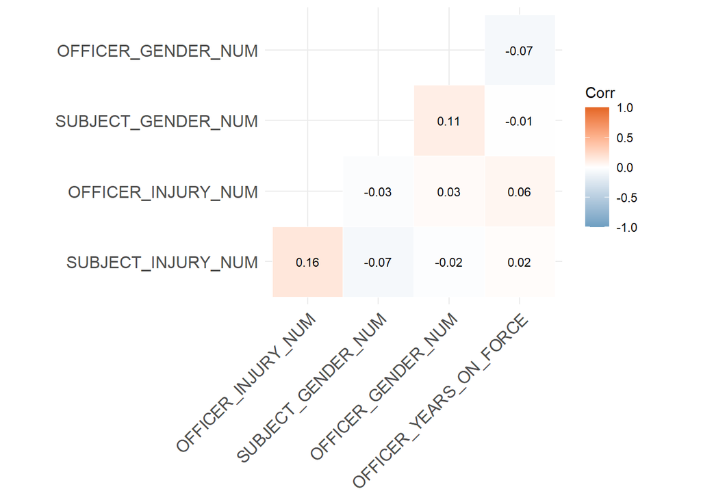

```r
#create a correlation matrix using the numerical versions of the information created earlier.
corrM <- cor(df[, c("SUBJECT_INJURY_NUM", "OFFICER_INJURY_NUM", "SUBJECT_GENDER_NUM", "OFFICER_GENDER_NUM", "OFFICER_YEARS_ON_FORCE")])
ggcorrplot(corrM, type = "lower", outline.col = "white", lab = TRUE, lab_size = 3, colors = c("#6D9EC1", "white", "#E46726"))
```

Here it appears there is little correlation between any of the major factors. The highest correlation identified is between subject injury and officer injury which likely means that increase the force used by one side, leads to an increase in force used by both side, making injury more common; this is to be expected and is easy to understand. Additionally, Officer experience appears to have almost no correlation with any other factor here, confirming our earlier analysis.

### Map of positional crime data

By plotting these crimes on a map, it should become clear if there are certain ‘crime hot-spots’.

[figure not shown]

```r
# Create a map using a list of co-ordinates and then ggmap to plot them, then use ggplot to plot the location of crime data.
bbox <- c(left=-97.01,bottom=32.62,right=-96.54,top=33.019)
map <- get_stamenmap(bbox, zoom = 11)
mapv=ggmap(map)+
  geom_point(aes(x= as.numeric(LOCATION_LONGITUDE), y= as.numeric(LOCATION_LATITUDE), alpha=0.8, color = "red"),
             data = df) +
  labs(title = "Positional Crime Data") +
  theme(legend.position="none")
mapv
```

Here we can see that the most crimes are committed in central Dallas, with other hot-spots in the urban areas. Additionally, areas that are close to green spaces appear to have lower levels of crime, this covers both areas close to natural green areas - such as the edge of the city - and areas which are close to parks or lakes.

### Spatial breakdown of crimes by race

By plotting a breakdown of crimes by race it should be easy to establish if different areas tend to be informally segregated along racial lines, or if Dallas is instead a well integrated, cosmopolitan city.

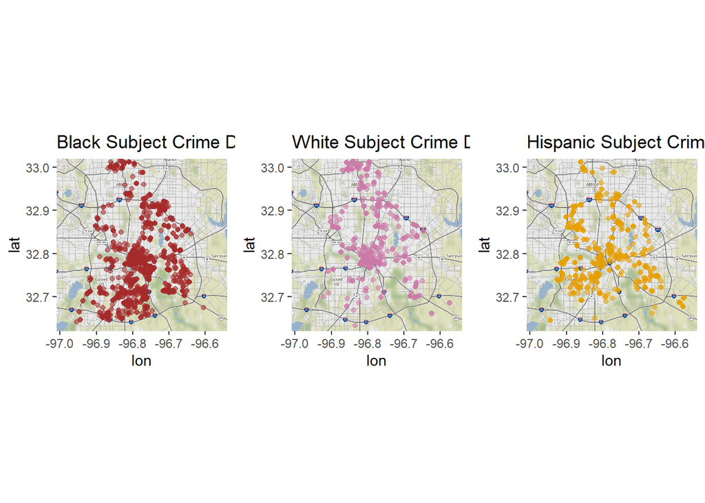

```r
#create a data frame of just crimes committed by X race, then use the code from the last section to plot spatial crime data by race, create one output containing all plots in 3 columns.
black_subjects <- subset(df, SUBJECT_RACE == "Black")
mapb <- ggmap(map) +
  geom_point(aes(x = as.numeric(LOCATION_LONGITUDE), y = as.numeric(LOCATION_LATITUDE), alpha = 0.8),
             data = black_subjects, color = "brown") +
  labs(title = "Black Subject Crime Data") +
  theme(legend.position = "none")

white_subjects <- subset(df, SUBJECT_RACE == "White")
mapw <- ggmap(map) +
  geom_point(aes(x = as.numeric(LOCATION_LONGITUDE), y = as.numeric(LOCATION_LATITUDE), alpha = 0.8),
             data = white_subjects, color = "#CC79A7") +
  labs(title = "White Subject Crime Data") +
  theme(legend.position = "none")

his_subjects <- subset(df, SUBJECT_RACE == "Hispanic")
maph <- ggmap(map) +
  geom_point(aes(x = as.numeric(LOCATION_LONGITUDE), y = as.numeric(LOCATION_LATITUDE), alpha = 0.8),
             data = his_subjects, color = "#E69F00") +
  labs(title = "Hispanic Subject Crime Data") +
  theme(legend.position = "none")

grid.arrange(mapb, mapw, maph, ncol=3)
```

Through mapping crime locations based on race, it appears that certain areas seem informally segregated along racial line. For example, Cedar Crest appears to be dominated mainly by Black crime, while Oak Cliff is more dominated by Hispanic crime, additionally there seems to be a disproportionate amount of white crime in the north of the city, compared with other races. Meanwhile central Dallas appears to be the most ‘cosmopolitan’ area, with large amounts of crime from all races.

### Demographic breakdown

There is a stereotype that police are mainly white, and subjects mainly black (or at least an over representation of both). Let’s see if that stereotype holds up under some basic analysis

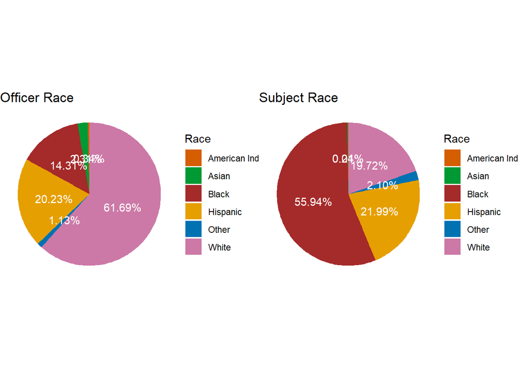

```r
#Use gglpot2 and gridExtra to create two pie charts arranged on one row, using the percentage breakdown of each race in OFFICER_RACE and SUBJECT_RACE
gridExtra::grid.arrange(grobs = list(
  ggplot(df, aes(x = factor(1), fill = OFFICER_RACE)) +
    geom_bar(width = 1, position = "fill") +
    scale_fill_manual(values = c("#D55E00", "#009933", "brown", "#E69F00", "#0072B2", "#CC79A7")) + #set own colours to more clearly identify differing races
    geom_text(stat = "count", aes(label = paste0(scales::percent(stat(count) / sum(stat(count))), "" , "")),
              position = position_fill(vjust = 0.5),color = "white") +
    coord_polar("y", start = 0) +
    theme_void() +
    ggtitle("Officer Race") +
    guides(fill = guide_legend(title = "Race")),
  ggplot(df, aes(x = factor(1), fill = SUBJECT_RACE)) +
    geom_bar(width = 1, position = "fill") +
    scale_fill_manual(values = c("#D55E00", "#009933", "brown", "#E69F00", "#0072B2", "#CC79A7")) +
    geom_text(stat = "count", aes(label = paste0(scales::percent(stat(count) / sum(stat(count))), "" , "")),
              position = position_fill(vjust = 0.5),color = "white") +
    coord_polar("y", start = 0) +
    theme_void() +
    ggtitle("Subject Race") +
    guides(fill = guide_legend(title = "Race"))),
  nrow = 1)
```

It appears true that white people do make up the majority of police officers, and are slightly over-represented compared to the population census [2]. Additionally, the subject race clearly shows an over-representation of black people given they only constitute 24% of the Dallas city population [2]. Hispanics appear to be the only race constituting a major percentage of the population that is fairly equally represented in both police and subjects. This could indeed be a sign of institutionalised bigotry within the police force as black people are both majorly underrepresented as officers and over-represented in crime statistics.

### Breakdown of subjects by race and gender, and their chances of injury

Its been established that different races are over-represented in crime statistics. By plotting subject’s chances of injury by different characteristics it can be establish if this over-representation continues, or if it was isolated.

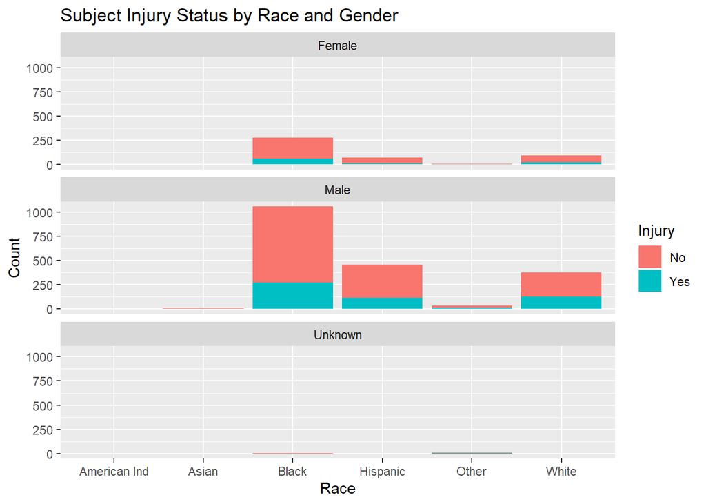

```r
#create a bar chart subject injury chance by race and gender
ggplot(df, aes(x = SUBJECT_RACE, fill = SUBJECT_INJURY)) +
  geom_bar(position = "stack") +
  facet_wrap(~ SUBJECT_GENDER, ncol = 1) +
  labs(title = "Subject Injury Status by Race and Gender",
       x = "Race",
       y = "Count",
       fill = "Injury")
```

### Subject and Officer Injury Chance Dependent on Subject and Officer Race

Lets breakdown the percentage chance of subject injury depending on subject race and the race of the officer, and then establish the officer injury chance depending on subject and officer race. Is there a noticeable difference between subject and officer injury chance depending on race?

```r
#create a table breaking down the percentage chance of subject injury dependent on officer and subject race. Use a filter to remove instances of less than 30 as any fewer instances might be considered to small a sample size to draw accurate conclusions from.
df_subject_injury <- df %>%
  group_by(OFFICER_RACE, SUBJECT_RACE) %>%
  summarize(TOTAL_INSTANCES = n(),
            SUBJECT_INJURED = sum(SUBJECT_INJURY == "Yes")) %>%
  filter(TOTAL_INSTANCES > 30) %>%
  ungroup() %>%
  mutate(PERCENTAGE = round(SUBJECT_INJURED / TOTAL_INSTANCES * 100, 2))
datatable(df_subject_injury,
          options = list(pageLength = 10, lengthChange = FALSE))
```

|  | OFFICER_RACE | SUBJECT_RACE | TOTAL_INSTANCES | SUBJECT_INJURED | PERCENTAGE |
| --- | --- | --- | --- | --- | --- |
| 1 | Black | Black | 201 | 53 | 26.37 |
| 2 | Black | Hispanic | 73 | 21 | 28.77 |
| 3 | Black | White | 57 | 22 | 38.6 |
| 4 | Hispanic | Black | 230 | 67 | 29.13 |
| 5 | Hispanic | Hispanic | 138 | 39 | 28.26 |
| 6 | Hispanic | White | 104 | 30 | 28.85 |
| 7 | White | Black | 846 | 198 | 23.4 |
| 8 | White | Hispanic | 302 | 62 | 20.53 |
| 9 | White | Other | 31 | 9 | 29.03 |
| 10 | White | White | 287 | 93 | 32.4 |

```r
#Repeat code above, switching round OFFICER_RACE and SUBJECT_RACE
df_officer_injury <- df %>%
  group_by(SUBJECT_RACE, OFFICER_RACE) %>%
  summarize(TOTAL_INSTANCES = n(),
            OFFICERS_INJURED = sum(OFFICER_INJURY == "Yes")) %>%
  filter(TOTAL_INSTANCES > 30) %>%
  ungroup() %>%
  mutate(PERCENTAGE = round(OFFICERS_INJURED / TOTAL_INSTANCES * 100, 2))
datatable(df_officer_injury,
          options = list(pageLength = 10, lengthChange = FALSE))
```

|  | SUBJECT_RACE | OFFICER_RACE | TOTAL_INSTANCES | OFFICERS_INJURED | PERCENTAGE |
| --- | --- | --- | --- | --- | --- |
| 1 | Black | Black | 201 | 15 | 7.46 |
| 2 | Black | Hispanic | 230 | 15 | 6.52 |
| 3 | Black | White | 846 | 83 | 9.81 |
| 4 | Hispanic | Black | 73 | 12 | 16.44 |
| 5 | Hispanic | Hispanic | 138 | 19 | 13.77 |
| 6 | Hispanic | White | 302 | 31 | 10.26 |
| 7 | Other | White | 31 | 4 | 12.9 |
| 8 | White | Black | 57 | 4 | 7.02 |
| 9 | White | Hispanic | 104 | 9 | 8.65 |
| 10 | White | White | 287 | 29 | 10.1 |

## Conclusion

To conclude, it is clear there is an issue of representation in Dallas. White people are clearly over-represented as police officers and under-represented in crime statistics, while the opposite is true of black people; people of other races do not appear to suffer from this representation crisis. This is obviously something that needs to be addressed, and is definitely an indicator of ingrained and institutional bigotry. Additionally, within Dallas as a whole, there appears to be an issue of informal segregation. It could be clearly seen that certain areas where crimes were committed were dominated by one race or another. Although the centre was fairly mixed, the further out of the centre the more likely it was an area was informally racially segregated - at least regarding crime data. While the latter is a large problem facing the Dallas area, the former is a problem which can be challenged immediately, and should be to ensure proper representation across the force and to reduce of the over-representation of black people as criminals. On a different note, surprisingly given the above findings, the statistics regarding subject injury seemed to show the opposite conclusion. Given the fact that one of the safest situations to be in as a subject is to be a black person engaging with a white officer, this could indicate that - while demographically Dallas favours white people - individually white officers take more care with black subjects, perhaps due to anti-racist pressures seen within the US as a whole. This is a good sign, and is something that should be looked upon favourably, as any sign that goes against stereotypes of racism should be. Finally and rather surprisingly, officer experience had very little influence on any of the factors tested in this report. Older officers do not seem any more likely to injure subjects or to significantly impact their interactions with subjects of differing characteristics. This clearly highlights that deeper study of other factors is required in the future, to better understand the influencing factors regarding Dallas PD’s interactions. Ultimately, while Dallas PD does have some worrying indications of institutional bigotry, there are some inspiring points to be identified, alongside the areas which clearly need improving.

## Bibliography

[1] https://www.kaggle.com/center-for-policing-equity/data-science-for-good

[2] https://www.census.gov/quickfacts/fact/table/dallascitytexas/PST045221#PST045221